# 고급회귀분석 12장

2025-04-07

## 12.4 자기상관

```r
source("functions/mult_reg.R", echo = TRUE)
```

[output not shown]

```r
source("functions/reg_diagnostics.R", echo = TRUE)
```

```
##
## > outliers = function(X, y, alpha = 0.05, MSE) {
## +     library(glue)
## +     n = dim(X)[1]
## +     p = dim(X)[2]
## +     s = sqrt(MSE)
## +     one = c(rep(1,  .... [TRUNCATED]
```

```r
source("functions/var_selection.R", echo = TRUE)
```

[output not shown]

### (예 12.1)

```r
x1 = c(133.6, 135.4, 137.6, 140.0, 143.8, 147.1, 148.8, 151.4, 153.3, 156.5,
       160.8, 163.6, 166.9, 171.4, 174.0, 175.4, 180.5, 184.9, 187.1, 188.7)
y = c(349.7, 353.5, 359.2, 366.4, 376.5, 385.7, 391.3, 398.9, 404.2, 414.0,
      423.4, 430.5, 440.4, 451.8, 457.0, 460.9, 462.9, 443.4, 445.0, 449.0)

X = cbind(x1) ; n = dim(X)[1] ; one = c(rep(1, n))
res = mult_reg(X, y, alpha = 0.05, coeff = TRUE)
```

```
##   요인    제곱합 자유도 평균제곱합      F값  F기각치
## 1 회귀 25042.632      1 25042.6319 148.7341 4.413873
## 2 잔차  3030.694     18   168.3719       NA       NA
## 3   계 28073.325     19         NA       NA       NA
## SST = 28073.3254999992, SSR = 25042.631873753, SSE = 3030.69362624681
## MSR = 25042.631873753, MSE = 168.371868124823
## F_0 = 148.734062006056, F_alpha = 4.41387341917057
```

```r
res$beta_hat ; y_hat = cbind(one, x1) %*% (res$beta_hat)
```

```
##          [,1]
## one 89.233935
## x1   2.024188
```

```r
e = y - y_hat ; # e

num = 0 ; denum = 0

for (i in 2:n){
  num = num + (e[i] - e[i-1])^2 ; denum = denum + (e[i])^2
}
d = num / denum ; d ; num ; denum
```

```
## [1] 0.3229567
```

```
## [1] 946.7098
```

```
## [1] 2931.383
```

```r
rho_num = 0 ; rho_denum = 0
for (i in 2:n){
  rho_num = rho_num + e[i-1] * e[i] ; rho_denum = rho_denum + (e[i-1])^2
}
rho_hat = rho_num / rho_denum ; rho_hat
```

```
## [1] 0.891002
```

```r
x1_prime = c(NA) ; y_prime = c(NA)
for (i in 2:n){
  x1_prime[i] = x1[i] - rho_hat * x1[i-1]
  y_prime[i] = y[i] - rho_hat * y[i-1]
}
x1_prime <- x1_prime[-1] ; y_prime <- y_prime[-1]

x1_prime_bar = mean(x1_prime) ; y_prime_bar = mean(y_prime)

beta_1_hat = sum((x1_prime - x1_prime_bar)*(y_prime - y_prime_bar)) / sum((x1_prime - x1_prime_bar)^2)
beta_0_hat = (y_prime_bar - x1_prime_bar * beta_1_hat)/(1 - rho_hat)

beta_0_hat ; beta_1_hat
```

```
## [1] 369.2316
```

```
## [1] 0.4862173
```

```r
x1_prime
```

```
##  [1] 16.36213 16.95832 17.39812 19.05971 18.97391 17.73360 18.81890 18.40229
##  [9] 19.90939 21.35818 20.32687 21.13207 22.69176 21.28225 20.36565 24.21824
## [17] 24.07413 22.35372 21.99352
```

## 12.5 R 실습

이 데이터는 R에 기본적으로 내장되어 있는 것으로 1947년부터 1962년까지 7가지의 경제학적 변수를 관측한 값으로 구성되어 있다. 반응변수는 고용자수(Employed), 설명변수는 국민총생산(GNP), 14세 이상의 인구수(Population)으로 할 때, GLS 추정량을 구해보자. 먼저 다음과 같은 중회귀모형을 가정해보자.

$$\begin{equation*}
\text{Employed}_i = \beta_0 + \beta_1 \times \text{GNP}_i + \beta_2
\times \text{Population}_i + \epsilon_i, \quad \epsilon_i \sim N(0,
\sigma^2), i = 1,\cdots, 16
\end{equation*}$$

```r
data("longley")
fit <- lm(Employed ~ GNP + Population, data = longley)
summary(fit, cor = T)
```

```
##
## Call:
## lm(formula = Employed ~ GNP + Population, data = longley)
##
## Residuals:
##      Min       1Q   Median       3Q      Max
## -0.80899 -0.33282 -0.02329  0.25895  1.08800
##
## Coefficients:
##             Estimate Std. Error t value Pr(>|t|)
## (Intercept) 88.93880   13.78503   6.452 2.16e-05 ***
## GNP          0.06317    0.01065   5.933 4.96e-05 ***
## Population  -0.40974    0.15214  -2.693   0.0184 *
## ---
## Signif. codes:  0 '***' 0.001 '**' 0.01 '*' 0.05 '.' 0.1 ' ' 1
##
## Residual standard error: 0.5459 on 13 degrees of freedom
## Multiple R-squared:  0.9791, Adjusted R-squared:  0.9758
## F-statistic: 303.9 on 2 and 13 DF,  p-value: 1.221e-11
##
## Correlation of Coefficients:
##            (Intercept) GNP
## GNP         0.98
## Population -1.00       -0.99
```

위 결과는 $\boldsymbol{\mathbf{\epsilon}} \sim N(\mathbf{0}, \sigma^2 I_n)$을 가정한 것으로 회귀계수 추정값의 상관계수를 살펴보면 $\widehat{\text{Corr}}(\hat{\beta}_0, \hat{\beta}_1) = 0.98$, $\widehat{\text{Corr}}(\hat{\beta}_0, \hat{\beta}_2) = -1.00$, $\widehat{\text{Corr}}(\hat{\beta}_1, \hat{\beta}_2) = -0.99$으로 추정값들 사이의 상관성이 매우 높음을 알 수 있다. 특히 시간에 따라 관측된 이 데이터는 오차 $\epsilon_i$간 다음과 같은 일차자기상관관계의 가정이 더 적절할 수 있다.

$$\begin{equation*}
\epsilon_i = \rho \epsilon_i + \delta_i, \quad \delta_i \sim N(0,
\sigma^2_{\delta})
\end{equation*}$$

이때, $\rho = 0$인지 알아보기 위해 Durbin-Watson 통계량으로 검정해보기로 한다. 이것은 `car`패키지를 설치하여 `DurbinWatsonTest()`함수를 사용하면 된다.

```r
library(car)
durbinWatsonTest(fit)
```

```
##  lag Autocorrelation D-W Statistic p-value
##    1       0.2878177      1.301484   0.052
##  Alternative hypothesis: rho != 0
```

```r
cor(fit$residuals[-16], fit$residuals[-1])
```

```
## [1] 0.3104092
```

이것은 $\hat{\rho} = \textstyle\sum_{i=2}^{n} e_i e_{i-1} / \textstyle\sum_{i=2}^{n} e^{2}_i$ 을 계산한 것이다. 이제 $V_{ij} = \rho^{|i-j|}$ 에서 $\rho$ 대신 $\hat{\rho} = 0.3104092$를 대입하면 다음과 같다.

```r
V <- diag(16)
V <-  0.3104092^abs(row(V) - col(V))

X <- model.matrix(fit)
V.inv <- solve(V)

beta <- solve(t(X) %*% V.inv %*% X) %*% t(X) %*% V.inv %*% longley$Employed # GLS 추정량

beta
```

```
##                    [,1]
## (Intercept) 94.89887752
## GNP          0.06738948
## Population  -0.47427391
```

GLS 추정량의 표준오차 $\sqrt{\widehat{\text{Var}}(\hat{\boldsymbol{\mathbf{\beta}}}^{*})} = \sqrt{\hat{\sigma}^2 (X^{\top} V^{-1}X)^{-1}}$ 는 다음과 같이 구할 수 있다.

```r
res <- longley$Employed - X %*% beta
sig <- sum(res^2) / fit$df
sqrt(diag(solve(t(X) %*% V.inv %*% X)) * sig)
```

```
## (Intercept)         GNP  Population
## 14.15760467  0.01086675  0.15572652
```

```r
# 분산 추정값
solve(t(X) %*% V.inv %*% X) * sig
```

```
##             (Intercept)           GNP   Population
## (Intercept) 200.4377700  0.1502621679 -2.201838109
## GNP           0.1502622  0.0001180863 -0.001668834
## Population   -2.2018381 -0.0016688336  0.024250750
```

## 연습문제

### 12.8

```r
x = c(seq(1, from = 0 , to = 9))
y = c(120, 135, 162, 181, 215, 234, 277, 313, 374, 422)

X = cbind(x) ; n = dim(X)[1] ; one = c(rep(1, n))
res = mult_reg(X, y, alpha = 0.05, coeff = TRUE)
```

```
##   요인    제곱합 자유도 평균제곱합      F값  F기각치
## 1 회귀 90106.694      1 90106.6939 224.3269 5.317655
## 2 잔차  3213.406      8   401.6758       NA       NA
## 3   계 93320.100      9         NA       NA       NA
## SST = 93320.0999999999, SSR = 90106.6939393937, SSE = 3213.40606060622
## MSR = 90106.6939393937, MSE = 401.675757575777
## F_0 = 224.326940921733, F_alpha = 5.31765507157871
```

```r
res$beta_hat ; y_hat = cbind(one, x) %*% (res$beta_hat)
```

```
##         [,1]
## one 94.58182
## x   33.04848
```

```r
e = y - y_hat ; # e

num = 0 ; denum = 0

for (i in 2:n){
  num = num + (e[i] - e[i-1])^2 ; denum = denum + (e[i])^2
}
d = num / denum # ; d ; num ; denum

rho_num = 0 ; rho_denum = 0
for (i in 2:n){
  rho_num = rho_num + e[i-1] * e[i] ; rho_denum = rho_denum + (e[i-1])^2
}
rho_hat = rho_num / rho_denum # ;  rho_hat

x1_prime = c(NA) ; y_prime = c(NA)
for (i in 2:n){
  x1_prime[i] = x[i] - rho_hat * x[i-1]
  y_prime[i] = y[i] - rho_hat * y[i-1]
}
x1_prime <- x1_prime[-1] ; y_prime <- y_prime[-1]

x1_prime_bar = mean(x1_prime) ; y_prime_bar = mean(y_prime)

beta_1_hat = sum((x1_prime - x1_prime_bar)*(y_prime - y_prime_bar)) / sum((x1_prime - x1_prime_bar)^2)
beta_0_hat = (y_prime_bar - x1_prime_bar * beta_1_hat)/(1 - rho_hat)

beta_0_hat ; beta_1_hat
```

```
## [1] 19.2026
```

```
## [1] 43.76035
```

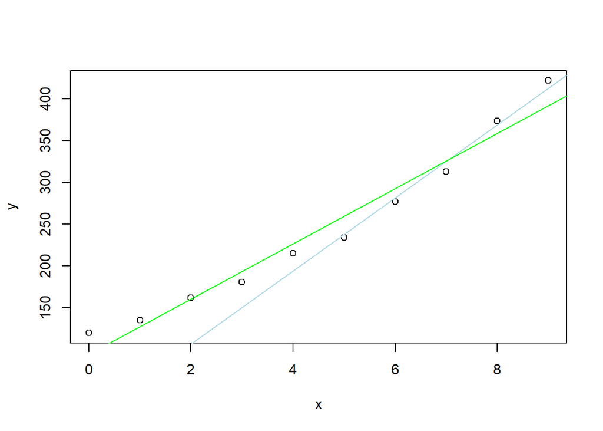

```r
plot(x, y, xlab= "x", ylab = "y")
abline(coef = c(beta_0_hat, beta_1_hat), col = "lightblue")
abline(coef = res$beta_hat, col = "green")
```

### 12.9

```r
x = c(127.3, 130.0, 132.7, 129.4, 135.0, 137.1, 141.2, 142.8, 145.5, 145.3,
      148.3, 146.4, 150.2, 153.1, 157.3, 160.7, 164.2, 165.6, 168.7, 171.7)
y = c(20.9, 21.4, 21.9, 21.5, 22.3, 22.7, 23.4, 23.6, 24.1, 24.0,
      24.5, 24.3, 25.0, 25.6, 26.3, 26.9, 27.5, 27.7, 28.2, 28.7)
```

#### 12.9 - (1)

```r
X = cbind(x) ; n = dim(X)[1] ; one = c(rep(1, n))
res = mult_reg(X, y, alpha = 0.05, coeff = TRUE)
```

```
##   요인      제곱합 자유도   평균제곱합     F값  F기각치
## 1 회귀 109.7860013      1 1.097860e+02 17723.5 4.413873
## 2 잔차   0.1114987     18 6.194373e-03      NA       NA
## 3   계 109.8975000     19           NA      NA       NA
## SST = 109.8975, SSR = 109.786001282792, SSE = 0.111498717208035
## MSR = 109.786001282792, MSE = 0.00619437317822415
## F_0 = 17723.5045619686, F_alpha = 4.41387341917057
```

```r
res$beta_hat ; y_hat = cbind(one, x) %*% (res$beta_hat)
```

```
##          [,1]
## one -1.443120
## x    0.175906
```

```r
e = y - y_hat ; # e

num = 0 ; denum = 0

for (i in 2:n){
  num = num + (e[i] - e[i-1])^2 ; denum = denum + (e[i])^2
}
d = num / denum ; d # num ; denum
```

```
## [1] 1.059432
```

#### 12.9 - (2)

```r
res$beta_hat
```

```
##          [,1]
## one -1.443120
## x    0.175906
```

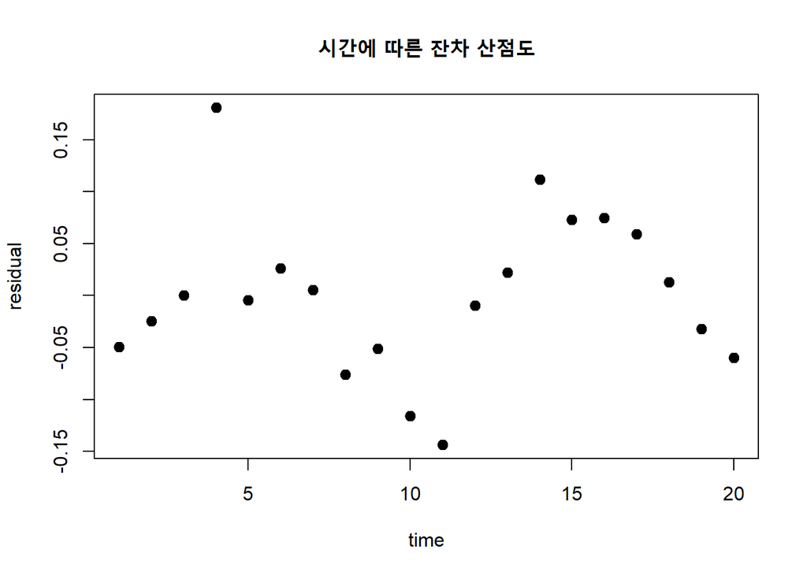

```r
time = c(seq(from =1, to = n, by = 1))

plot(x = time, y = e, xlab = "time", ylab = "residual",
     main = "시간에 따른 잔차 산점도", pch = 19, cex = 1.2)
```

#### 12.9 - (3)

```r
rho_num = 0 ; rho_denum = 0
for (i in 2:n){
  rho_num = rho_num + e[i-1] * e[i] ; rho_denum = rho_denum + (e[i-1])^2
}
rho_hat = rho_num / rho_denum # ; rho_hat

x1_prime = c(NA) ; y_prime = c(NA)
for (i in 2:n){
  x1_prime[i] = x[i] - rho_hat * x[i-1]
  y_prime[i] = y[i] - rho_hat * y[i-1]
}
x1_prime <- x1_prime[-1] ; y_prime <- y_prime[-1]

x1_prime_bar = mean(x1_prime) ; y_prime_bar = mean(y_prime)

beta_1_hat = sum((x1_prime - x1_prime_bar)*(y_prime - y_prime_bar)) / sum((x1_prime - x1_prime_bar)^2)
beta_0_hat = (y_prime_bar - x1_prime_bar * beta_1_hat)/(1 - rho_hat)

beta_0_hat ; beta_1_hat
```

```
## [1] -1.144173
```

```
## [1] 0.1739373
```

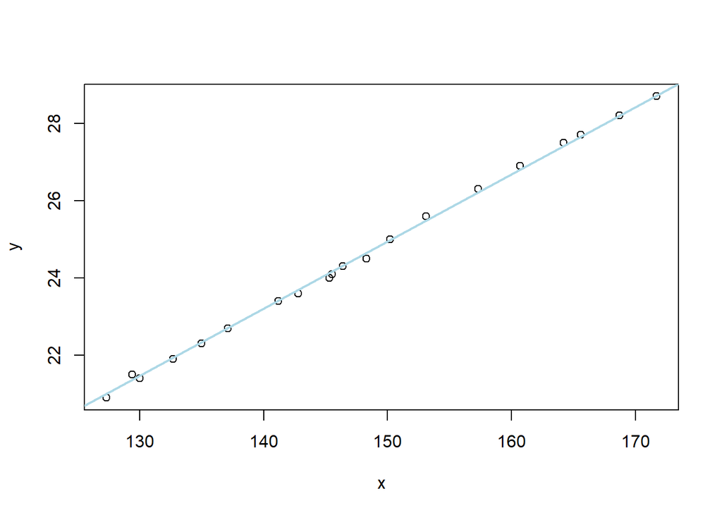

```r
plot(x, y, xlab= "x", ylab = "y")
abline(coef = c(beta_0_hat, beta_1_hat), col = "lightblue", lwd = 2)
```

```r
# abline(coef = res$beta_hat, col = "green", lwd = 2.5)
# legend()
```

#### 12.9 - (4)

```r
# 정밀도 행렬을 생성하는 함수 정의
generate_precision_matrix <- function(rho, n) {
  # n이 1인 경우
  if(n == 1){
    return(matrix(1 / (1 - rho^2), nrow = 1, ncol = 1))
  }

  # n x n 크기의 0 행렬 생성
  Sigma_inv <- matrix(0, n, n)

  # 첫번째와 마지막 대각원소 설정
  Sigma_inv[1, 1]   <- 1
  Sigma_inv[n, n]   <- 1

  # 첫번째 행과 마지막 행의 off-diagonal 원소 설정
  Sigma_inv[1, 2]   <- -rho
  Sigma_inv[n, n-1] <- -rho

  # n > 2 인 경우, 중간 행들에 대해 내부 대각원소와 인접 off-diagonals 설정
  if(n > 2){
    for(i in 2:(n-1)) {
      Sigma_inv[i, i]     <- (1 + rho^2)
      Sigma_inv[i, i - 1] <- -rho
      Sigma_inv[i, i + 1] <- -rho
    }
  }

  return(Sigma_inv / (1 - rho^2))
}

# # 예시: n과 rho_hat 값 설정
# n <- 5
# rho_hat <- 0.7
#
# # 함수 호출을 통해 정밀도 행렬 생성
# Sigma_inv <- generate_precision_matrix(rho_hat, n)
#
# # 생성된 행렬 출력
# print(Sigma_inv)
```

```r
res$MSE * solve(res$XtX)
```

```
##               one             x
## one  0.0383576837 -2.577339e-04
## x   -0.0002577339  1.745869e-06
```

```r
X = cbind(one, X)

# # Toeplitz 행렬 생성: 첫번째 열을 생성합니다.
# first_column <- rho_hat^(0:(n-1))
#
# # toeplitz() 함수를 사용하여 Toeplitz 행렬 생성
# V_hat <- toeplitz(first_column)
# V_hat_inv = solve(V_hat)
# # 결과 행렬 출력
# print(V_hat_inv)
rho_hat ; n
```

```
## [1] 0.4699754
```

```
## [1] 20
```

```r
V_hat_inv = generate_precision_matrix(rho_hat, n)
sol = solve(t(X) %*% V_hat_inv %*% X) * res$MSE
print(sol)
```

```
##               one             x
## one  0.0799732696 -5.358335e-04
## x   -0.0005358335  3.625943e-06
```

```r
# 정밀도 행렬을 생성하는 함수 정의
generate_precision_matrix <- function(rho, n) {
  # n이 1인 경우
  if(n == 1){
    return(matrix(1 / (1 - rho^2), nrow = 1, ncol = 1))
  }

  # n x n 크기의 0 행렬 생성
  Sigma_inv <- matrix(0, n, n)

  # 첫번째와 마지막 대각원소 설정
  Sigma_inv[1, 1]   <- 1
  Sigma_inv[n, n]   <- 1

  # 첫번째 행과 마지막 행의 off-diagonal 원소 설정
  Sigma_inv[1, 2]   <- -rho
  Sigma_inv[n, n-1] <- -rho

  # n > 2 인 경우, 중간 행들에 대해 내부 대각원소와 인접 off-diagonals 설정
  if(n > 2){
    for(i in 2:(n-1)) {
      Sigma_inv[i, i]     <- (1 + rho^2)
      Sigma_inv[i, i - 1] <- -rho
      Sigma_inv[i, i + 1] <- -rho
    }
  }

  return(Sigma_inv / (1 - rho^2))
}

# 예시: n과 rho_hat 값 설정
n <- 5
rho_hat <- 0.7

# 함수 호출을 통해 정밀도 행렬 생성
Sigma_inv <- generate_precision_matrix(rho_hat, n)

# 생성된 행렬 출력
print(Sigma_inv)
```

```
##           [,1]      [,2]      [,3]      [,4]      [,5]
## [1,]  1.960784 -1.372549  0.000000  0.000000  0.000000
## [2,] -1.372549  2.921569 -1.372549  0.000000  0.000000
## [3,]  0.000000 -1.372549  2.921569 -1.372549  0.000000
## [4,]  0.000000  0.000000 -1.372549  2.921569 -1.372549
## [5,]  0.000000  0.000000  0.000000 -1.372549  1.960784
```

### 12.14

```r
x1 = c(133.6, 135.4, 137.6, 140.0, 143.8, 147.1, 148.8, 151.4, 153.3, 156.5,
       160.8, 163.6, 166.9, 171.4, 174.0, 175.4, 180.5, 184.9, 187.1, 188.7)
y = c(349.7, 353.5, 359.2, 366.4, 376.5, 385.7, 391.3, 398.9, 404.2, 414.0,
      423.4, 430.5, 440.4, 451.8, 457.0, 460.9, 462.9, 443.4, 445.0, 449.0)
```

#### 12.14 - (1)

```r
X = cbind(x1) ; n = dim(X)[1] ; one = c(rep(1, n))
res = mult_reg(X, y, alpha = 0.05, coeff = TRUE)
```

```
##   요인    제곱합 자유도 평균제곱합      F값  F기각치
## 1 회귀 25042.632      1 25042.6319 148.7341 4.413873
## 2 잔차  3030.694     18   168.3719       NA       NA
## 3   계 28073.325     19         NA       NA       NA
## SST = 28073.3254999992, SSR = 25042.631873753, SSE = 3030.69362624681
## MSR = 25042.631873753, MSE = 168.371868124823
## F_0 = 148.734062006056, F_alpha = 4.41387341917057
```

```r
res$beta_hat
```

```
##          [,1]
## one 89.233935
## x1   2.024188
```

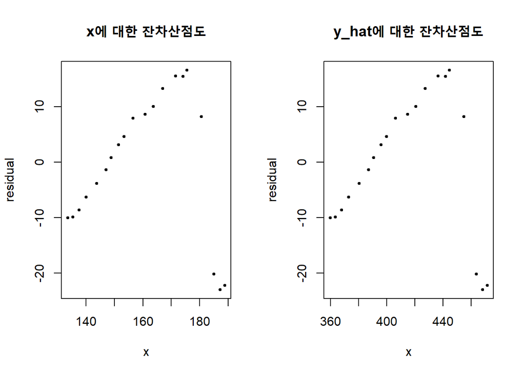

```r
y_hat = cbind(one, x1) %*% res$beta_hat

e = y - y_hat

par(mfrow = c(1,2))
plot(x = x1, y = e, xlab = "x", ylab= "residual",
     main = "x에 대한 잔차산점도", pch = 19, cex = 0.5)
plot(x = y_hat, y = e, xlab = "x", ylab= "residual",
     main = "y_hat에 대한 잔차산점도", pch = 19, cex = 0.5)
```

우선 산점도를 그려봤을때 오차항 간에 상관관계가 있는 것으로 보이나 일차자기상관이 있는지는 Durbin-Watson 검정을 통해 확인해본다

```r
num = 0 ; denum = 0

for (i in 2:n){
  num = num + (e[i] - e[i-1])^2 ; denum = denum + (e[i])^2
}
d = num / denum ; d # ; num ; denum
```

```
## [1] 0.3229567
```

$d = 0.3229567$ < $d_L = 1.20$ 이므로 귀무가설 $H_0 : \rho = 0$을 기각하고 $H_1 : \rho > 0$을 채택한다. 즉 유의수준 $\alpha = 0.05$에서 오차 간 일차자기상관관계가 있다고 할 수 있다.

#### 12.14 - (2)

```r
rho_num = 0 ; rho_denum = 0
for (i in 2:n){
  rho_num = rho_num + e[i-1] * e[i] ; rho_denum = rho_denum + (e[i-1])^2
}
rho_hat = rho_num / rho_denum ; rho_hat
```

```
## [1] 0.891002
```

```r
V_hat_inv = generate_precision_matrix(rho_hat, n)

X = cbind(one, x1)
beta_hat_gls = solve(t(X) %*% V_hat_inv %*% X) %*% t(X) %*% V_hat_inv %*% y

beta_hat_gls
```

```
##           [,1]
## one 131.745681
## x1    1.714326
```

계산결과 $\hat{\rho} = 0.891002$를 대입해서 $\widehat{V}^{-1}$를 구한 결과는 위의 R 코드 참조. $V$대신에 $\widehat{V}^{-1}$를 대입하여 $\hat{\beta}^{GLS} = (X^{\top} V^{-1} X )^{-1} X^{\top} V^{-1} \mathbf{y}$ 을 계산한 결과는 $\hat{\beta}^{GLS}_0 = 131.745681$, $\hat{\beta}^{GLS}_1 = 1.714326$ 이다.

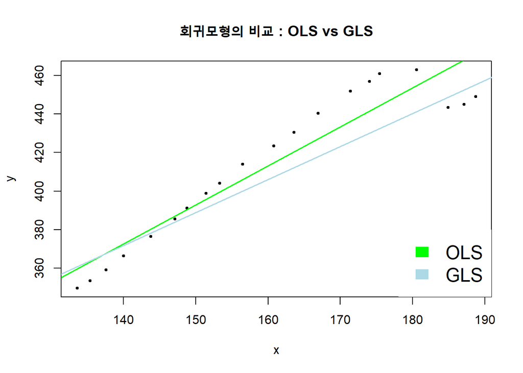

```r
plot(x = x1, y = y, xlab = "x", ylab = "y", main = "회귀모형의 비교 : OLS vs GLS", pch = 19, cex= 0.5)
abline(coef = res$beta_hat, col = "green", lwd = 1.5)
abline(coef = beta_hat_gls, col = "lightblue", lwd = 1.5)
legend("bottomright",legend=c("OLS","GLS"),fill=c("green","lightblue"),border="white",box.lty=0,cex=1.5)
```